# Tarea 06

1. **Proporciones.** Usaremos datos de reincidencia en conducta criminal del estado de Iowa, este estado sigue a los delincuentes por un periodo de 3 años y registra el número de días hasta reincidencia para aquellos que son readmitidos en prisión. El departamento de correcciones utiliza los datos de reincidencia para evaluar sus programas de prevención de recaída en conducta criminal.

Los datos Recidivism contienen información de todos los delincuentes condenados por dos tipos de delito durante 2010 (*Recid* indica si recayeron en conducta criminal).

```r
library(tidyverse)
library(patchwork)
recidivism <- read_csv("Recidivism.csv")
set.seed(4)

recidivism <- recidivism %>%
  mutate(Recid_n = case_when(
    Recid == "Yes" ~ 1,
    Recid == "No" ~ 0
  ))

muestra_reincidencia <- sample_n(recidivism, 25) %>% select(Recid_n)
N <- nrow(recidivism)

estimar_total <- function(muestra_reincidencia, N){
  total_muestral <- sum(muestra_reincidencia$Recid_n)
  n <- nrow(muestra_reincidencia)
  f_exp <- N / n
  estimador_total <- total_muestral / n
  res <- tibble(total_muestra = total_muestral,
    factor_exp = f_exp,
    est_total_porciento = estimador_total * 100)
  res
}
estimar_total(muestra_reincidencia, N) %>%
  mutate(across(where(is.numeric), round, 2))
```

```
## # A tibble: 1 × 3
##   total_muestra factor_exp est_total_porciento
##           <dbl>      <dbl>               <dbl>
## 1             9       681.                  36
```

```r
replicar_muestreo <- function(recidivism, m = 500, n){
  resultados <- map_df(1:m,
    function(id) {
      sample_n(recidivism, n) |>
        estimar_total(N)
    }, .id = "id_muestra")
}
replicar_muestreo(recidivism, m = 10, n = 25) |>
  mutate(across(where(is.numeric), round, 1))
```

```
## # A tibble: 10 × 4
##    id_muestra total_muestra factor_exp est_total_porciento
##    <chr>              <dbl>      <dbl>               <dbl>
##  1 1                     16       681.                  64
##  2 2                     11       681.                  44
##  3 3                      8       681.                  32
##  4 4                      6       681.                  24
##  5 5                      8       681.                  32
##  6 6                     10       681.                  40
##  7 7                      5       681.                  20
##  8 8                     10       681.                  40
##  9 9                      5       681.                  20
## 10 10                     7       681.                  28
```

```r
# 25 y 250
replicaciones_1 <- replicar_muestreo(recidivism, m = 1500, n = 25)
replicaciones_2 <- replicar_muestreo(recidivism, m = 1500, n = 250)

total_pob <- sum(recidivism |> pull(Recid_n)) / nrow(recidivism)*100
#gráficas
graf_1 <- ggplot(replicaciones_1, aes(x = est_total_porciento)) +
  geom_histogram() +
  geom_vline(xintercept = total_pob, colour = "red") +
  xlab("% de reincidencia")
  scale_x_continuous(breaks = seq(0, 80, 10), limits = c(0, 80))
```

```
## <ScaleContinuousPosition>
##  Range:
##  Limits:    0 --   80
```

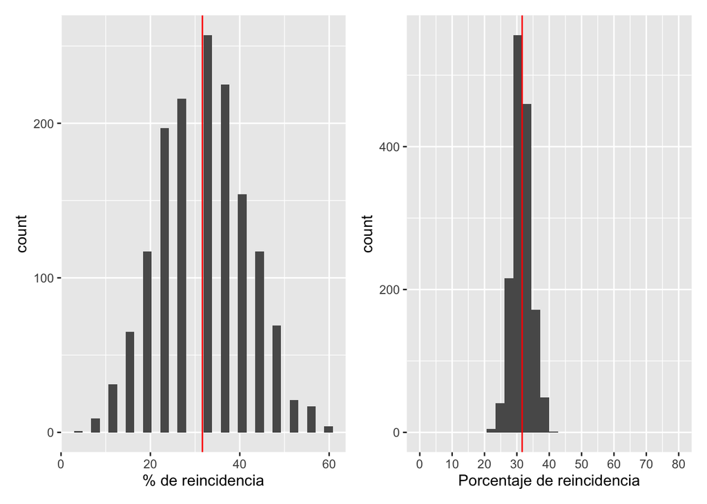

```r
graf_2 <- ggplot(replicaciones_2, aes(x = est_total_porciento)) +
  geom_histogram() +
  geom_vline(xintercept = total_pob, colour = "red") +
  xlab("Porcentaje de reincidencia") +
  scale_x_continuous(breaks = seq(0, 80, 10), limits = c(0, 80))
graf_1 + graf_2
```

```r
# Error Estándar
ee_1 <- replicaciones_1 |> pull(est_total_porciento) |> sd()
ee_2 <- replicaciones_2 |> pull(est_total_porciento) |> sd()
sprintf("Error Estándar: ee_1 = %0.0f, ee_2 = %0.0f",
  ee_1, ee_2)
```

```
## [1] "Error Estándar: ee_1 = 10, ee_2 = 3"
```

```r
# Error Estándar Teórico
mu1 <- mean(replicaciones_1$est_total_porciento)
s1 <- sd(replicaciones_1$est_total_porciento)
eeT_1 <- sqrt(( (mu1/100) * (1-mu1/100)) / 25)*100
mu2 <- mean(replicaciones_2$est_total_porciento)
s2 <- sd(replicaciones_2$est_total_porciento)
eeT_2 <- sqrt(( (mu2/100) * (1-mu2/100)) / 250)*100
sprintf("Error Estándar Teórico: eeT_1 = %0.0f, eeT_2 = %0.0f",
  eeT_1, eeT_2)
```

```
## [1] "Error Estándar Teórico: eeT_1 = 9, eeT_2 = 3"
```

```r
sprintf("Diff: 1 = %.4f, 2 = %.4f",
  (ee_1-eeT_1), (ee_2-eeT_2))
```

```
## [1] "Diff: 1 = 0.2461, 2 = -0.0412"
```

2. **Mezcla de distribuciones**. Imaginemos que nuestro modelo teórico es una mezcla de dos poblaciones, una gamma y una normal

```r
muestrear_pob <- function(n){
  u <- runif(n) # número aleatorio
  map_dbl(u, ~ ifelse(.x < 1/2, rgamma(1, 5, 0.1), rnorm(1, 100, 5)))
}
```

El modelo teórico se puede graficar, pero también podemos obetener una aproximación buena haciendo una cantidad grande de simulaciones

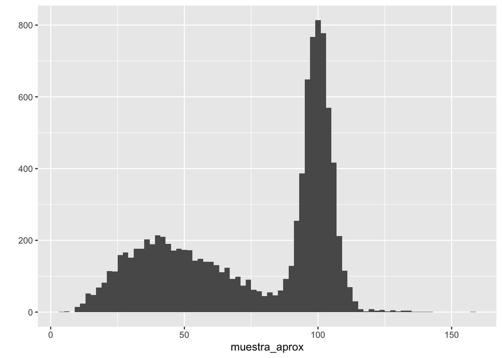

```r
muestra_aprox <- muestrear_pob(10000)
qplot(muestra_aprox, binwidth= 2)
```

Ahora consideramos estimar la media de esta distribución con un muestra de tamaño 50. ¿Cómo se ve la distribución de muestreo de la media? Grafica un histograma y una gráfica cuantil-cuantil normal.

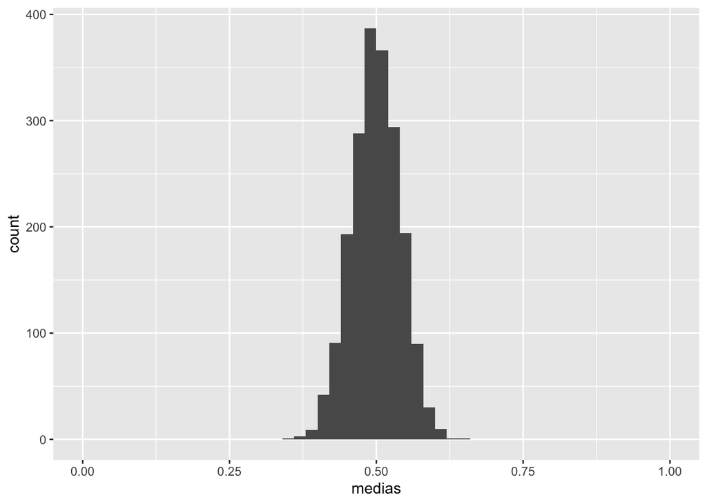

```r
medias <- map_dbl(1:2000,  ~ mean(runif(50)))

ggplot(tibble(medias)) +
  geom_histogram(aes(x = medias), breaks = seq(0, 1, 0.02))
```

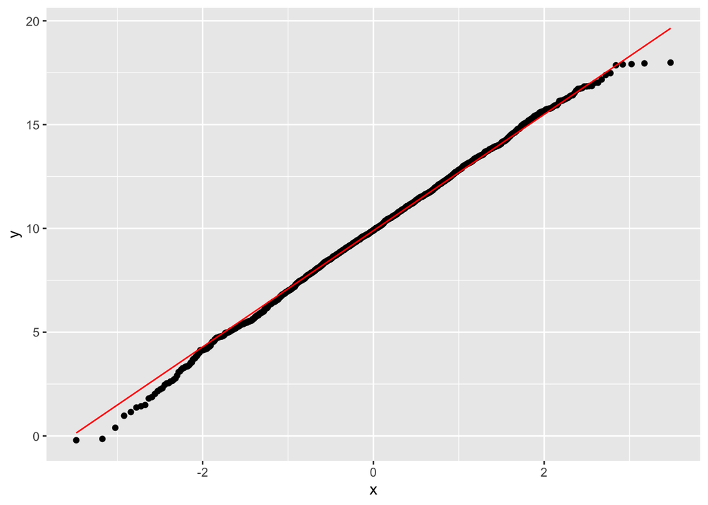

```r
muestra2 <- tibble(x_1 = rnorm(2000, 10, 3), x_2 = medias)
graf_1 <- ggplot(muestra2, aes(sample = x_1)) +
  geom_qq(distribution = stats::qnorm) +
  geom_qq_line(colour = "red")
graf_1
```

3. **El error estándar de una media.** Supongamos que $x$ es una variable aleatoria que toma valores en los reales con distribución de probabilidad $F$. Denotamos por $\mu$ y $\sigma^2$ la media y varianza de $F$,

$$\mu = E(x),$$
$$\sigma^2=var(x)=E[(x-\mu)^2]$$

Ahora, sea $(X_1,...,X_n)$ una muestra aleatoria de $F$, de tamaño $n$, la media de la muestra $\bar{X}=\sum_{i=1}^nX_i/n$ tiene:

- esperanza $\mu$,
- varianza $\sigma^2/n$.

En palabras: la esperanza de $\bar{X}$ es la misma que la esperanza de $x$, pero la varianza de $\bar{X}$ es $1/n$ veces la varianza de $x$, así que entre mayor es la $n$ tenemos una mejor estimación de $\mu$.

En el caso del estimador de la media $\bar{X}$, el error estándar quedaría

$$ee(\bar{X}) = [var(\bar{X})]^{1/2}=
\sigma/ \sqrt{n}.$$
Entonces,

- Consideramos los datos de ENLACE edo. de México (ENLACE era una prueba estandarizada que se aplicaba a todos los alumnos de primaria en México), y la columna de calificaciones de español 3<sup>o</sup> de primaria (`esp_3`).

```r
enlace <- read_csv("enlace_15.csv")
glimpse(enlace)
```

```
## Rows: 7,518
## Columns: 8
## $ id       <dbl> 38570, 38571, 38572, 38573, 38574, 38575, 38576, 38577, 38578…
## $ cve_ent  <dbl> 15, 15, 15, 15, 15, 15, 15, 15, 15, 15, 15, 15, 15, 15, 15, 1…
## $ turno    <chr> "MATUTINO", "MATUTINO", "MATUTINO", "MATUTINO", "MATUTINO", "…
## $ tipo     <chr> "INDêGENA", "INDêGENA", "INDêGENA", "INDêGENA", "INDêGENA", "…
## $ esp_3    <dbl> 550, 485, 462, 646, 508, 502, 570, 441, 597, 648, 535, 430, 4…
## $ esp_6    <dbl> 483, 490, 385, 613, 452, 500, 454, 427, 582, 614, 443, 562, 4…
## $ n_eval_3 <dbl> 13, 17, 9, 33, 26, 10, 65, 82, 132, 16, 16, 6, 10, 27, 10, 1,…
## $ n_eval_6 <dbl> 19, 18, 9, 26, 35, 13, 49, 78, 110, 18, 9, 2, 12, 34, 9, 6, 7…
```

- Genera un histograma de las calificaciones de 3<sup>o</sup> de primaria. Calcula la media y la desviación estándar.

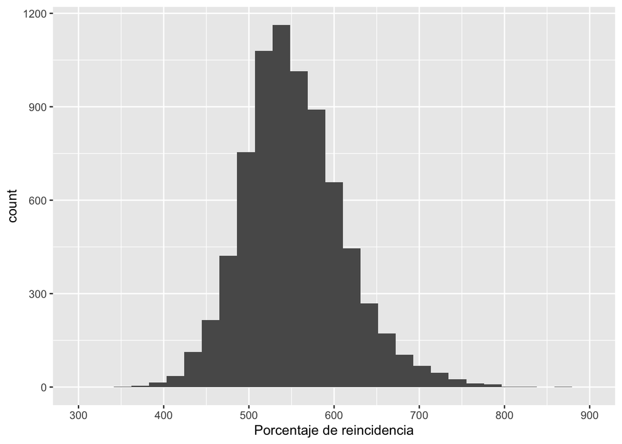

  ```r
  enlace <- select(enlace, esp_3)
  graf <- ggplot(enlace, aes(x = esp_3)) +
    geom_histogram() +
    xlab("Porcentaje de reincidencia") +
    scale_x_continuous(breaks = seq(300, 900, 100), limits = c(300, 900))
  graf
  ```

```r
mu <- mean(enlace$esp_3)
s <- sd(enlace$esp_3)
sprintf("Media: %0.4f, Desvest: %0.4f",
  mu, s)
```

```
## [1] "Media: 552.9911, Desvest: 59.2580"
```

- Para tamaños de muestra $n = 10, 100, 1000$:
- Aproximareos la distribución muestral:
1. simula 5,000 muestras aleatorias (con reemplazo), ii) calcula la media en cada muestra, iii) Realiza un histograma de la distribución muestral de las medias (las medias del paso anterior) iv) aproxima el error estándar calculando la desviación estándar de las medias del paso ii.

```r
#i)
estimar_total <- function(enlace, N){
  n <- nrow(enlace)
  prom_muestral <- sum(enlace$esp_3)/n
  f_exp <- N / n
  estimador_total <- prom_muestral
  res <- tibble(prom_muestral = prom_muestral,
    factor_exp = f_exp,
    tamaño_muestra = n)
  res
}
replicar_muestreo_media <- function(enlace, m, n){
  resultados <- map_df(1:m,
    function(id) {
      sample_n(enlace, n) |>
        estimar_total(N)
    }, .id = "id_muestra")
}
replicaciones_10 <- replicar_muestreo_media(enlace, m = 5000, n = 10)
replicaciones_100 <- replicar_muestreo_media(enlace, m = 5000, n = 100)
replicaciones_1000 <- replicar_muestreo_media(enlace, m = 5000, n = 1000)
```

```r
#ii)
sprintf("medias: 10=>%0.4f, 100=>%0.4f, 1000=>%0.4f",
        mean(replicaciones_10$prom_muestral),mean(replicaciones_100$prom_muestral),
        mean(replicaciones_1000$prom_muestral))
```

```
## [1] "medias: 10=>552.9994, 100=>552.8779, 1000=>553.0098"
```

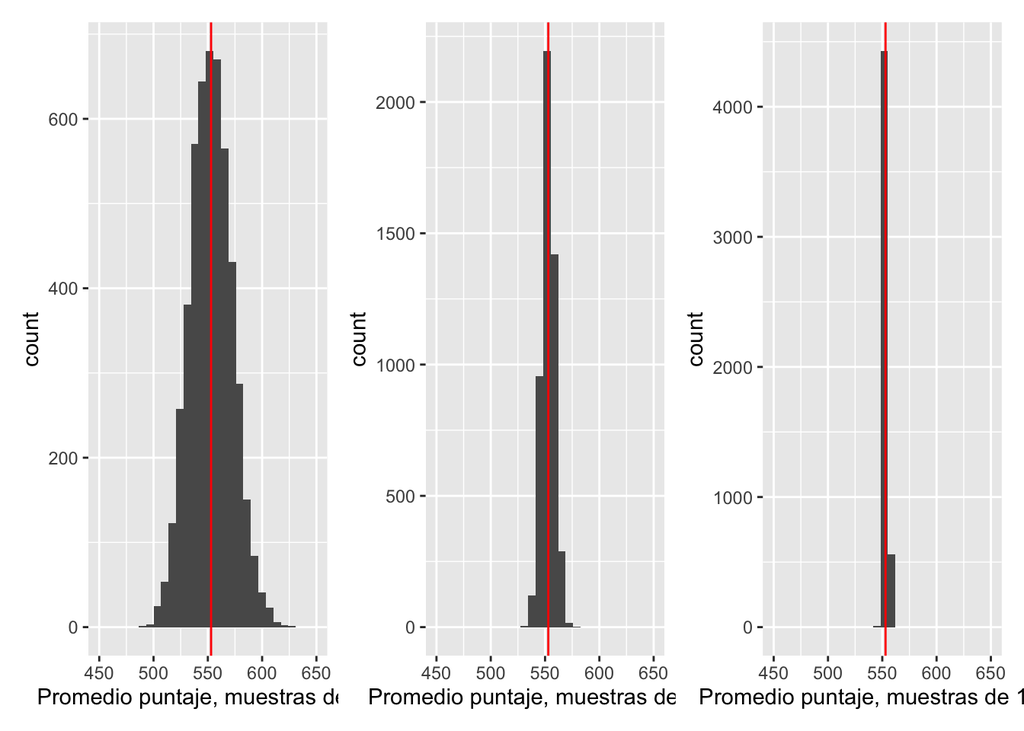

```r
#iii)
graf_1 <- ggplot(replicaciones_10, aes(x = prom_muestral)) +
  geom_histogram() +
  geom_vline(xintercept = mu, colour = "red") +
  xlab("Promedio puntaje, muestras de 10") +
  scale_x_continuous(breaks = seq(450, 650, 50), limits = c(450, 650))
graf_2 <- ggplot(replicaciones_100, aes(x = prom_muestral)) +
  geom_histogram() +
  geom_vline(xintercept = mu, colour = "red") +
  xlab("Promedio puntaje, muestras de 100") +
  scale_x_continuous(breaks = seq(450, 650, 50), limits = c(450, 650))
graf_3 <- ggplot(replicaciones_1000, aes(x = prom_muestral)) +
  geom_histogram() +
  geom_vline(xintercept = mu, colour = "red") +
  xlab("Promedio puntaje, muestras de 1000") +
  scale_x_continuous(breaks = seq(450, 650, 50), limits = c(450, 650))
graf_1 + graf_2 + graf_3
```

- Calcula el error estándar de la media para cada tamaño de muestra usando la fórmula derivada arriba y compara con tus simulaciones.

```r
s10 <- sd(replicaciones_10$prom_muestral)
s100 <- sd(replicaciones_100$prom_muestral)
s1000 <- sd(replicaciones_1000$prom_muestral)
s10_t <- s / sqrt(10)
s100_t <- s / sqrt(100)
s1000_t <- s / sqrt(1000)
table <- data.frame(
  n = c("10", "100", "1000"),
  s = c(s10, s100, s1000),
  st = c(s10_t, s100_t, s1000_t),
  diff_ = c(s10-s10_t, s100-s100_t, s1000-s1000_t)
)
print(table)
```

```
##      n         s        st       diff_
## 1   10 19.216620 18.739017  0.47760306
## 2  100  5.899467  5.925797 -0.02633038
## 3 1000  1.740058  1.873902 -0.13384396
```

- ¿Cómo se comparan los errores estándar correspondientes a los distintos tamaños de muestra?

  Disminuye conforme el tamaño de la muestra